# Customer Segmentaiton K-means

## Customer Segementation Clustering

GITHUB Repository : https://github.com/PrakashBehara2001/CodeClauseInternship_DataScience

LinkedIn : https://www.linkedin.com/in/vedprakash-behara-485122263/

Dataset Source : https://www.kaggle.com/datasets/kaushiksuresh147/customer-segmentation

Project Id : #CC69853

## Description of K-MEANS :

Machine learning has two different process to deal with data, in which supervised and un-supervised are classified. K-means comes under un-supervised learning.

## K-means

It is an unsupervised machine learning algorithm, which doesn't have a target variable to describe the data. This requires accurate segmentations of the data by taking Unlabeled data as an input and to perform clustering techniques.

## Clustering

The process of dividing the data points into a number of groups such that data points in the same groups are more or like similar.

## Finding K value

To find the number of clusters, the k has to be assainged with different values to check the optimum accuracy. Elbow method has been used inorder to achieve this.

## Elbow method

Elbow Method is to determine the number of k values(centroids) to use in a k-means clustering algorithm. In this method k will be iterative from k=1 to k=n. For every value of k, we calculate the within-cluster sum of squares (WCSS) value.

we represent this values in a curve with Number of clusters as x-axis and WCSS value as Y-axis. This graph shows the point where the value of k is responsible for a drastic change.

This is a sample graph of this elbow method :

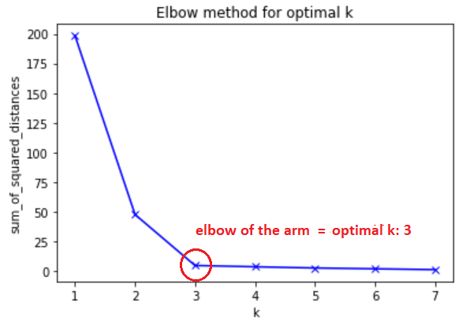

## Clustering Process

1. The process includes enabling the algorithm from unclassified data.
2. The idea is to form clusters with similar data points using centroid method by calculating Euclidean distance.
3. Indetail, all the data will be segmented into groups or clusters which has a centroid. This is an iterative process. It will be repeated with every data point calculating distance between centroid of the clusters and the data point.
4. The one which has minimum distance belongs to that cluster. And the centroid will be updated with the addition of new value as well.

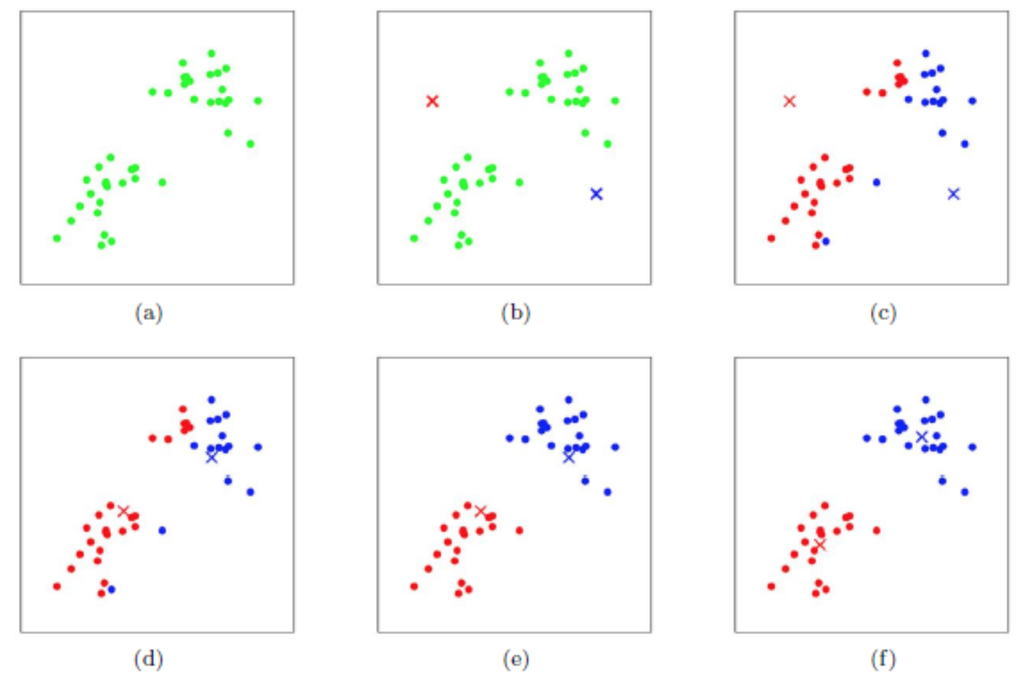

## Importing required libraries

```python
# pandas and numpy works with Data analizing and interpreting

import pandas as pd
import numpy as np

# for Data Visualization we use matplotlib, seaborn

import matplotlib.pyplot as plt
%matplotlib inline
import seaborn as sns

# preprocessing techniques to impute the data and for scaling

from sklearn.preprocessing import Normalizer
from sklearn.preprocessing import LabelEncoder
from sklearn.preprocessing import MinMaxScaler

from sklearn.cluster import KMeans
from yellowbrick.cluster import KElbowVisualizer

# Principle component analysis

from sklearn.decomposition import PCA
```

## Ignore Future Warnings

```python
import warnings

warnings.filterwarnings('ignore')
```

## All about the dataset

An automobile company has plans to enter new market with their existing products. After intensive market research, they’ve deduced that the behavior of the new market is similar to their existing market.

In their existing market, the sales team has classified all customers into 4 segments. Then, they performed segmented outreach and communication for a different segment of customers.

You are required to help the manager to predict the right group of the customers.

## Content

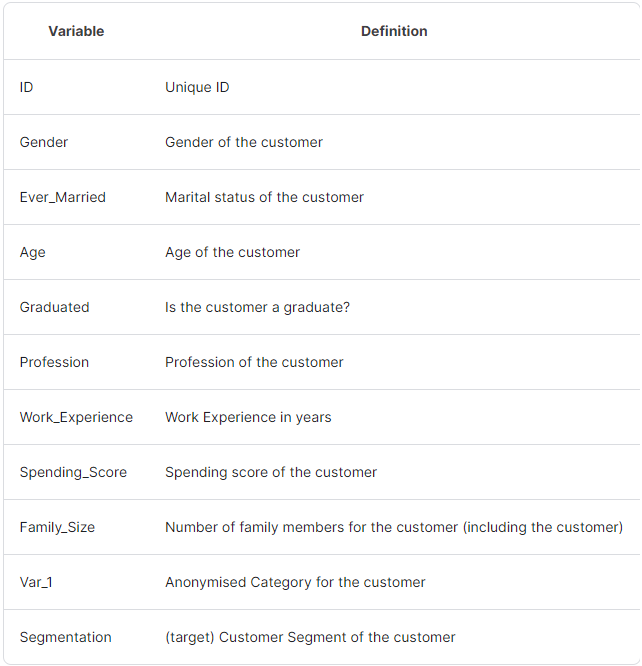

```python
d=pd.read_csv("D:/python cls recordings/datasets/Customer Segmentation - kaggle.csv")
```

## Copy data to unchange the original

```python
df = d.copy()
```

## Exploratory Data Analysis

```python
df
```

|  | Unnamed: 0 | ID | Gender | Ever_Married | Age | Graduated | Profession | Work_Experience | Spending_Score | Family_Size | Var_1 | Segmentation |
| --- | --- | --- | --- | --- | --- | --- | --- | --- | --- | --- | --- | --- |
| 0 | 0 | 460394 | Female | No | 32 | Yes | Healthcare | 9.0 | Low | 3.0 | Cat_6 | D |
| 1 | 1 | 461798 | Female | No | 56 | Yes | Artist | 0.0 | Low | 1.0 | Cat_6 | A |
| 2 | 2 | 464976 | Male | Yes | 75 | No | Lawyer | 1.0 | Low | 1.0 | Cat_4 | D |
| 3 | 3 | 462104 | Male | Yes | 39 | No | Entertainment | 9.0 | Low | 2.0 | Cat_3 | D |
| 4 | 4 | 464829 | Male | No | 22 | No | Healthcare | 9.0 | Low | 5.0 | Cat_4 | D |
| ... | ... | ... | ... | ... | ... | ... | ... | ... | ... | ... | ... | ... |
| 10690 | 10690 | 462861 | Female | No | 30 | Yes | Healthcare | 8.0 | Low | 1.0 | Cat_6 | D |
| 10691 | 10691 | 464409 | Female | Yes | 81 | Yes | Lawyer | 0.0 | Average | 2.0 | Cat_6 | A |
| 10692 | 10692 | 465861 | Female | No | 40 | Yes | Entertainment | 14.0 | Low | 1.0 | Cat_6 | A |
| 10693 | 10693 | 465056 | Male | Yes | 87 | Yes | Lawyer | 1.0 | High | 2.0 | Cat_6 | A |
| 10694 | 10694 | 461637 | Male | Yes | 51 | Yes | Artist | 1.0 | Low | 2.0 | Cat_7 | B |

10695 rows × 12 columns

```python
df.dtypes
```

```
Unnamed: 0           int64
ID                   int64
Gender              object
Ever_Married        object
Age                  int64
Graduated           object
Profession          object
Work_Experience    float64
Spending_Score      object
Family_Size        float64
Var_1               object
Segmentation        object
dtype: object
```

```python
df.shape
```

```
(10695, 12)
```

```python
df.head()
```

|  | Unnamed: 0 | ID | Gender | Ever_Married | Age | Graduated | Profession | Work_Experience | Spending_Score | Family_Size | Var_1 | Segmentation |
| --- | --- | --- | --- | --- | --- | --- | --- | --- | --- | --- | --- | --- |
| 0 | 0 | 460394 | Female | No | 32 | Yes | Healthcare | 9.0 | Low | 3.0 | Cat_6 | D |
| 1 | 1 | 461798 | Female | No | 56 | Yes | Artist | 0.0 | Low | 1.0 | Cat_6 | A |
| 2 | 2 | 464976 | Male | Yes | 75 | No | Lawyer | 1.0 | Low | 1.0 | Cat_4 | D |
| 3 | 3 | 462104 | Male | Yes | 39 | No | Entertainment | 9.0 | Low | 2.0 | Cat_3 | D |
| 4 | 4 | 464829 | Male | No | 22 | No | Healthcare | 9.0 | Low | 5.0 | Cat_4 | D |

```python
df.size
```

```
128340
```

```python
df.columns = ['S.no','ID','Gender','Ever_Married','Age','Graduated','Profession','Work_Experience',
            'Spending_Score','Family_Size','Var_1','Segmentation']
```

```python
df.set_index('S.no',inplace = True)
```

```python
df.info()
```

```
<class 'pandas.core.frame.DataFrame'>
Int64Index: 10695 entries, 0 to 10694
Data columns (total 11 columns):
 #   Column           Non-Null Count  Dtype
---  ------           --------------  -----
 0   ID               10695 non-null  int64
 1   Gender           10695 non-null  object
 2   Ever_Married     10505 non-null  object
 3   Age              10695 non-null  int64
 4   Graduated        10593 non-null  object
 5   Profession       10533 non-null  object
 6   Work_Experience  9597 non-null   float64
 7   Spending_Score   10695 non-null  object
 8   Family_Size      10247 non-null  float64
 9   Var_1            10587 non-null  object
 10  Segmentation     10695 non-null  object
dtypes: float64(2), int64(2), object(7)
memory usage: 1002.7+ KB
```

```python
df.describe()
```

|  | ID | Age | Work_Experience | Family_Size |
| --- | --- | --- | --- | --- |
| count | 10695.000000 | 10695.000000 | 9597.000000 | 10247.000000 |
| mean | 463468.088640 | 43.511828 | 2.619777 | 2.844052 |
| std | 2600.966411 | 16.774158 | 3.390790 | 1.536427 |
| min | 458982.000000 | 18.000000 | 0.000000 | 1.000000 |
| 25% | 461220.500000 | 30.000000 | 0.000000 | 2.000000 |
| 50% | 463451.000000 | 41.000000 | 1.000000 | 3.000000 |
| 75% | 465733.500000 | 53.000000 | 4.000000 | 4.000000 |
| max | 467974.000000 | 89.000000 | 14.000000 | 9.000000 |

```python
df['ID'].value_counts()
```

```
460394    2
462941    2
462452    2
465658    2
460211    2
         ..
461062    1
465424    1
464461    1
463634    1
465056    1
Name: ID, Length: 8363, dtype: int64
```

```python
df['ID'].describe()
```

```
count     10695.000000
mean     463468.088640
std        2600.966411
min      458982.000000
25%      461220.500000
50%      463451.000000
75%      465733.500000
max      467974.000000
Name: ID, dtype: float64
```

```python
df['Gender'].value_counts()
```

```
Male      5841
Female    4854
Name: Gender, dtype: int64
```

```python
df['Gender'].describe()
```

```
count     10695
unique        2
top        Male
freq       5841
Name: Gender, dtype: object
```

```python
df['Gender'].value_counts(normalize=True)
```

```
Male      0.546143
Female    0.453857
Name: Gender, dtype: float64
```

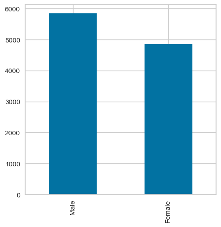

```python
df['Gender'].value_counts().plot.bar(figsize=(5,5))
```

```python
df['Age'].value_counts()
```

```
35    321
42    320
37    304
43    301
40    300
     ...
75     37
76     36
78     36
80     33
85     32
Name: Age, Length: 67, dtype: int64
```

```python
df['Age'].describe()
```

```
count    10695.000000
mean        43.511828
std         16.774158
min         18.000000
25%         30.000000
50%         41.000000
75%         53.000000
max         89.000000
Name: Age, dtype: float64
```

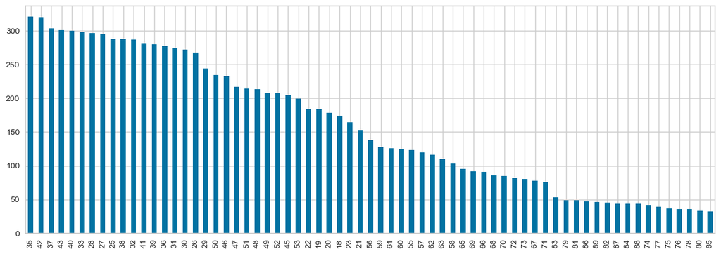

```python
df['Age'].value_counts().plot.bar(figsize=(15,5))
```

## Creating bins to classify and visualize better

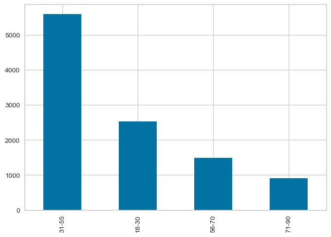

```python
bins = [18,30,55,70,90]

group = ['18-30','31-55','56-70','71-90']

df['age_group'] = pd.cut(df['Age'],bins,labels = group)
df['age_group'].value_counts().plot.bar()
```

## Dropping bins to make data uneffected

```python
df.drop(['age_group'],axis = 1, inplace = True)
```

```python
df
```

| S.no | ID | Gender | Ever_Married | Age | Graduated | Profession | Work_Experience | Spending_Score | Family_Size | Var_1 | Segmentation |
| --- | --- | --- | --- | --- | --- | --- | --- | --- | --- | --- | --- |
| 0 | 460394 | Female | No | 32 | Yes | Healthcare | 9.0 | Low | 3.0 | Cat_6 | D |
| 1 | 461798 | Female | No | 56 | Yes | Artist | 0.0 | Low | 1.0 | Cat_6 | A |
| 2 | 464976 | Male | Yes | 75 | No | Lawyer | 1.0 | Low | 1.0 | Cat_4 | D |
| 3 | 462104 | Male | Yes | 39 | No | Entertainment | 9.0 | Low | 2.0 | Cat_3 | D |
| 4 | 464829 | Male | No | 22 | No | Healthcare | 9.0 | Low | 5.0 | Cat_4 | D |
| ... | ... | ... | ... | ... | ... | ... | ... | ... | ... | ... | ... |
| 10690 | 462861 | Female | No | 30 | Yes | Healthcare | 8.0 | Low | 1.0 | Cat_6 | D |
| 10691 | 464409 | Female | Yes | 81 | Yes | Lawyer | 0.0 | Average | 2.0 | Cat_6 | A |
| 10692 | 465861 | Female | No | 40 | Yes | Entertainment | 14.0 | Low | 1.0 | Cat_6 | A |
| 10693 | 465056 | Male | Yes | 87 | Yes | Lawyer | 1.0 | High | 2.0 | Cat_6 | A |
| 10694 | 461637 | Male | Yes | 51 | Yes | Artist | 1.0 | Low | 2.0 | Cat_7 | B |

10695 rows × 11 columns

```python
df['Ever_Married'].value_counts()
```

```
Yes    6163
No     4342
Name: Ever_Married, dtype: int64
```

```python
df['Ever_Married'].describe()
```

```
count     10505
unique        2
top         Yes
freq       6163
Name: Ever_Married, dtype: object
```

```python
df['Ever_Married'].value_counts(normalize=True)
```

```
Yes    0.586673
No     0.413327
Name: Ever_Married, dtype: float64
```

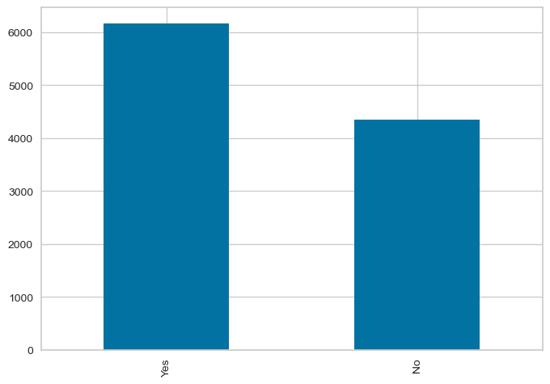

```python
df['Ever_Married'].value_counts().plot.bar()
```

```python
df['Graduated'].value_counts()
```

```
Yes    6570
No     4023
Name: Graduated, dtype: int64
```

```python
df['Graduated'].describe()
```

```
count     10593
unique        2
top         Yes
freq       6570
Name: Graduated, dtype: object
```

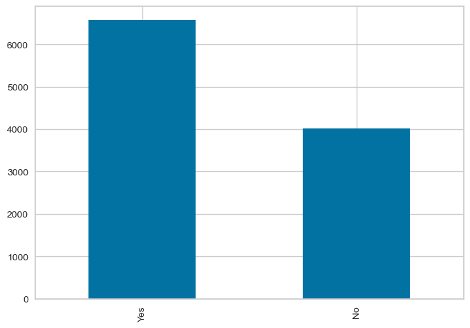

```python
df['Graduated'].value_counts().plot.bar()
```

```python
df['Profession'].value_counts()
```

```
Artist           3318
Healthcare       1750
Entertainment    1250
Engineer          935
Doctor            930
Lawyer            844
Executive         775
Marketing         403
Homemaker         328
Name: Profession, dtype: int64
```

```python
df['Profession'].value_counts(normalize=True)
```

```
Artist           0.315010
Healthcare       0.166144
Entertainment    0.118675
Engineer         0.088769
Doctor           0.088294
Lawyer           0.080129
Executive        0.073578
Marketing        0.038261
Homemaker        0.031140
Name: Profession, dtype: float64
```

```python
df['Profession'].describe()
```

```
count      10533
unique         9
top       Artist
freq        3318
Name: Profession, dtype: object
```

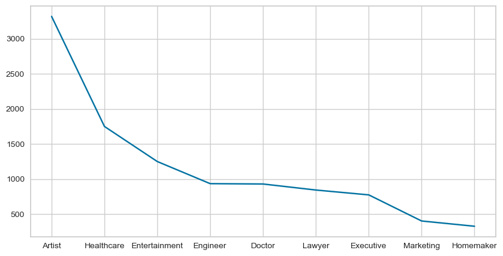

```python
df['Profession'].value_counts().plot(figsize=(10,5))
```

```python
df['Work_Experience'].value_counts()
```

```
1.0     3127
0.0     3087
9.0      613
8.0      612
2.0      373
4.0      346
3.0      337
5.0      270
6.0      265
7.0      256
14.0      66
10.0      64
11.0      64
12.0      60
13.0      57
Name: Work_Experience, dtype: int64
```

```python
df['Work_Experience'].describe()
```

```
count    9597.000000
mean        2.619777
std         3.390790
min         0.000000
25%         0.000000
50%         1.000000
75%         4.000000
max        14.000000
Name: Work_Experience, dtype: float64
```

```python
df['Work_Experience'].describe()
```

```
count    9597.000000
mean        2.619777
std         3.390790
min         0.000000
25%         0.000000
50%         1.000000
75%         4.000000
max        14.000000
Name: Work_Experience, dtype: float64
```

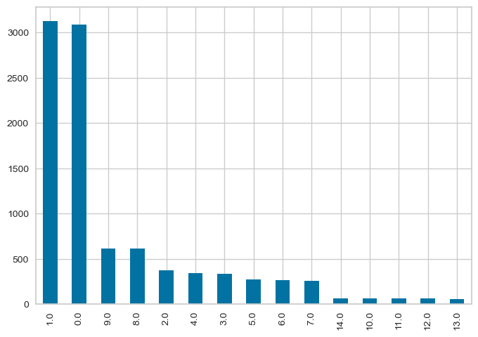

```python
df['Work_Experience'].value_counts().plot.bar()
```

```python
df['Spending_Score'].value_counts()
```

```
Low        6494
Average    2599
High       1602
Name: Spending_Score, dtype: int64
```

```python
df['Spending_Score'].value_counts(normalize=True)
```

```
Low        0.607200
Average    0.243011
High       0.149790
Name: Spending_Score, dtype: float64
```

```python
df['Spending_Score'].describe()
```

```
count     10695
unique        3
top         Low
freq       6494
Name: Spending_Score, dtype: object
```

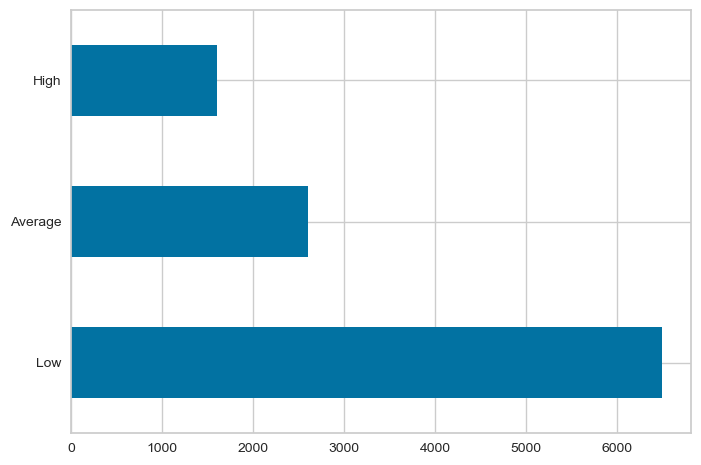

```python
df['Spending_Score'].value_counts().plot.barh()
```

```python
df['Family_Size'].value_counts()
```

```
2.0    3158
1.0    1965
3.0    1952
4.0    1823
5.0     812
6.0     290
7.0     122
8.0      65
9.0      60
Name: Family_Size, dtype: int64
```

```python
df['Family_Size'].describe()
```

```
count    10247.000000
mean         2.844052
std          1.536427
min          1.000000
25%          2.000000
50%          3.000000
75%          4.000000
max          9.000000
Name: Family_Size, dtype: float64
```

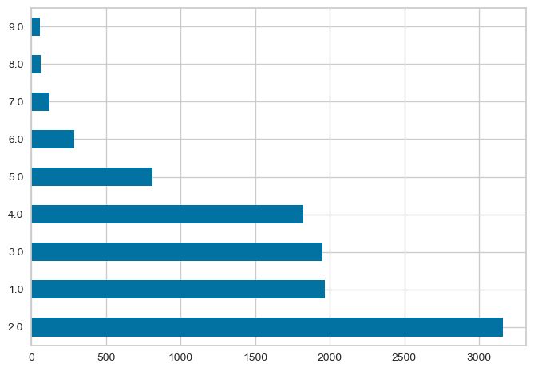

```python
df['Family_Size'].value_counts().plot.barh()
```

```python
df['Var_1'].value_counts()
```

```
Cat_6    6910
Cat_4    1475
Cat_3    1089
Cat_2     563
Cat_7     269
Cat_1     167
Cat_5     114
Name: Var_1, dtype: int64
```

```python
df['Var_1'].describe()
```

```
count     10587
unique        7
top       Cat_6
freq       6910
Name: Var_1, dtype: object
```

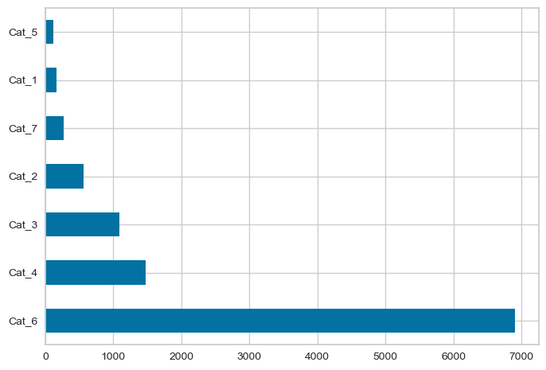

```python
df['Var_1'].value_counts().plot.barh()
```

## Checking for null values

```python
df.isnull().sum()
```

```
ID                    0
Gender                0
Ever_Married        190
Age                   0
Graduated           102
Profession          162
Work_Experience    1098
Spending_Score        0
Family_Size         448
Var_1               108
Segmentation          0
dtype: int64
```

The "Work Experience" column contains relatively more missing values than other columns. So behalf of that column let's Impute the data in other columns using Statistical methods.

## Imputing null values

```python
df['Ever_Married'].fillna(df['Ever_Married'].mode()[0],inplace = True)

df['Graduated'].fillna(df['Graduated'].mode()[0],inplace = True)

df['Profession'].fillna(df['Profession'].mode()[0],inplace = True)

df['Family_Size'].fillna(df['Family_Size'].mode()[0],inplace = True)

df['Var_1'].fillna(df['Var_1'].mode()[0],inplace = True)
```

```python
df.isnull().sum()
```

```
ID                    0
Gender                0
Ever_Married          0
Age                   0
Graduated             0
Profession            0
Work_Experience    1098
Spending_Score        0
Family_Size           0
Var_1                 0
Segmentation          0
dtype: int64
```

The imputation cannot be done in that column because the modified data can effect the whole data set, which is not a proper procedure. So, just remove the null values in the "Work_Experiennce" column.

```python
df.dropna(inplace = True)
```

```python
df.isnull().sum()
```

```
ID                 0
Gender             0
Ever_Married       0
Age                0
Graduated          0
Profession         0
Work_Experience    0
Spending_Score     0
Family_Size        0
Var_1              0
Segmentation       0
dtype: int64
```

Now we have no null values in the dataset. Hence we can proceed further with remaining process.

## Feature Engineering

As this is the existing market dataset the segementation is done already. So for working on the clustering process this column should be featured seperately and after encoding it can be dropped.

```python
x = df
y = df['Segmentation']
```

```python
x
```

| S.no | ID | Gender | Ever_Married | Age | Graduated | Profession | Work_Experience | Spending_Score | Family_Size | Var_1 | Segmentation |
| --- | --- | --- | --- | --- | --- | --- | --- | --- | --- | --- | --- |
| 0 | 460394 | Female | No | 32 | Yes | Healthcare | 9.0 | Low | 3.0 | Cat_6 | D |
| 1 | 461798 | Female | No | 56 | Yes | Artist | 0.0 | Low | 1.0 | Cat_6 | A |
| 2 | 464976 | Male | Yes | 75 | No | Lawyer | 1.0 | Low | 1.0 | Cat_4 | D |
| 3 | 462104 | Male | Yes | 39 | No | Entertainment | 9.0 | Low | 2.0 | Cat_3 | D |
| 4 | 464829 | Male | No | 22 | No | Healthcare | 9.0 | Low | 5.0 | Cat_4 | D |
| ... | ... | ... | ... | ... | ... | ... | ... | ... | ... | ... | ... |
| 10690 | 462861 | Female | No | 30 | Yes | Healthcare | 8.0 | Low | 1.0 | Cat_6 | D |
| 10691 | 464409 | Female | Yes | 81 | Yes | Lawyer | 0.0 | Average | 2.0 | Cat_6 | A |
| 10692 | 465861 | Female | No | 40 | Yes | Entertainment | 14.0 | Low | 1.0 | Cat_6 | A |
| 10693 | 465056 | Male | Yes | 87 | Yes | Lawyer | 1.0 | High | 2.0 | Cat_6 | A |
| 10694 | 461637 | Male | Yes | 51 | Yes | Artist | 1.0 | Low | 2.0 | Cat_7 | B |

9597 rows × 11 columns

```python
y
```

```
S.no
0        D
1        A
2        D
3        D
4        D
        ..
10690    D
10691    A
10692    A
10693    A
10694    B
Name: Segmentation, Length: 9597, dtype: object
```

```python
df_1 = x.copy()
```

## Label Encoding

```python
le=LabelEncoder()

x['Gender'] = le.fit_transform(x['Gender'])

x['Ever_Married'] = le.fit_transform(x['Ever_Married'])

x['Graduated'] = le.fit_transform(x['Graduated'])

x['Profession'] = le.fit_transform(x['Profession'])

x['Spending_Score'] = le.fit_transform(x['Spending_Score'])

x['Var_1'] = le.fit_transform(x['Spending_Score'])

x['Segmentation'] = le.fit_transform(x['Segmentation'])

y = le.fit_transform(y)
```

## Checking the Correlation of columns

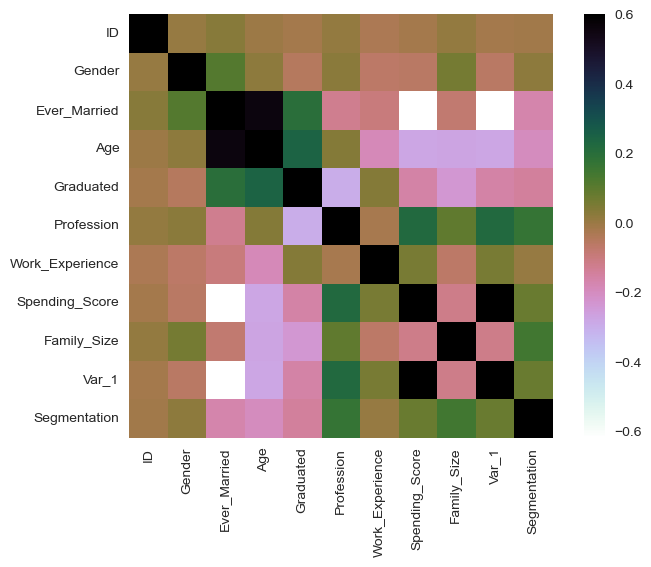

```python
matrix = x.corr()

sns.heatmap(matrix,vmax=.6,square=True,cmap='cubehelix_r')
```

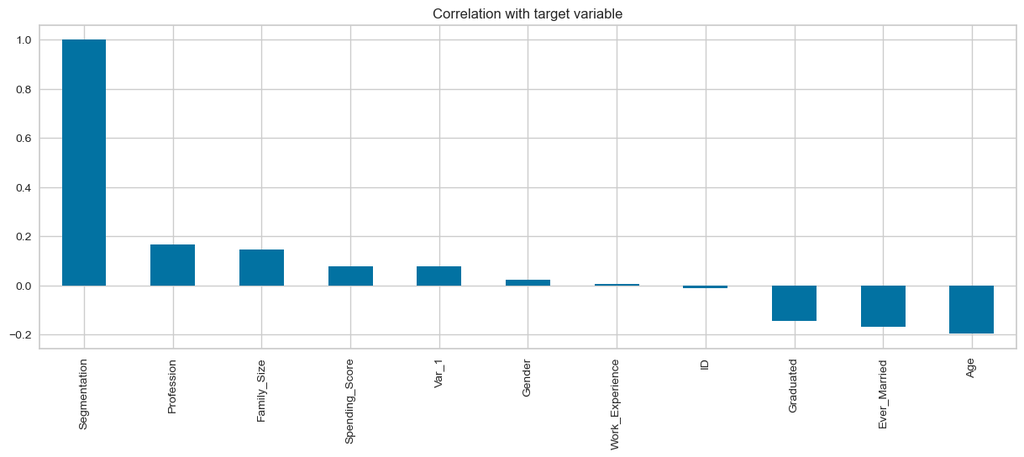

```python
target_corr = df.corrwith(x['Segmentation'])

target_corr.sort_values(ascending=False).plot(kind='bar', figsize=(15, 5))

plt.title('Correlation with target variable')
plt.show()
```

```python
x = x.drop(['Segmentation'],axis = 1)
```

```python
x = x.drop(['ID'],axis = 1)
```

```python
x
```

| S.no | Gender | Ever_Married | Age | Graduated | Profession | Work_Experience | Spending_Score | Family_Size | Var_1 |
| --- | --- | --- | --- | --- | --- | --- | --- | --- | --- |
| 0 | 0 | 0 | 32 | 1 | 5 | 9.0 | 2 | 3.0 | 2 |
| 1 | 0 | 0 | 56 | 1 | 0 | 0.0 | 2 | 1.0 | 2 |
| 2 | 1 | 1 | 75 | 0 | 7 | 1.0 | 2 | 1.0 | 2 |
| 3 | 1 | 1 | 39 | 0 | 3 | 9.0 | 2 | 2.0 | 2 |
| 4 | 1 | 0 | 22 | 0 | 5 | 9.0 | 2 | 5.0 | 2 |
| ... | ... | ... | ... | ... | ... | ... | ... | ... | ... |
| 10690 | 0 | 0 | 30 | 1 | 5 | 8.0 | 2 | 1.0 | 2 |
| 10691 | 0 | 1 | 81 | 1 | 7 | 0.0 | 0 | 2.0 | 0 |
| 10692 | 0 | 0 | 40 | 1 | 3 | 14.0 | 2 | 1.0 | 2 |
| 10693 | 1 | 1 | 87 | 1 | 7 | 1.0 | 1 | 2.0 | 1 |
| 10694 | 1 | 1 | 51 | 1 | 0 | 1.0 | 2 | 2.0 | 2 |

9597 rows × 9 columns

```python
x.dtypes
```

```
Gender               int32
Ever_Married         int32
Age                  int64
Graduated            int32
Profession           int32
Work_Experience    float64
Spending_Score       int32
Family_Size        float64
Var_1                int64
dtype: object
```

```python
x.head()
```

| S.no | Gender | Ever_Married | Age | Graduated | Profession | Work_Experience | Spending_Score | Family_Size | Var_1 |
| --- | --- | --- | --- | --- | --- | --- | --- | --- | --- |
| 0 | 0 | 0 | 32 | 1 | 5 | 9.0 | 2 | 3.0 | 2 |
| 1 | 0 | 0 | 56 | 1 | 0 | 0.0 | 2 | 1.0 | 2 |
| 2 | 1 | 1 | 75 | 0 | 7 | 1.0 | 2 | 1.0 | 2 |
| 3 | 1 | 1 | 39 | 0 | 3 | 9.0 | 2 | 2.0 | 2 |
| 4 | 1 | 0 | 22 | 0 | 5 | 9.0 | 2 | 5.0 | 2 |

```python
y
```

```
array([3, 0, 3, ..., 0, 0, 1])
```

```python
col = x.columns
```

```python
col
```

```
Index(['Gender', 'Ever_Married', 'Age', 'Graduated', 'Profession',
       'Work_Experience', 'Spending_Score', 'Family_Size', 'Var_1'],
      dtype='object')
```

## Scaling the data using MinMaxScaler

```python
M = MinMaxScaler()

X1 = M.fit_transform(x)
```

```python
X = pd.DataFrame(X1, columns = [col])
```

```python
X.head()
```

|  | Gender | Ever_Married | Age | Graduated | Profession | Work_Experience | Spending_Score | Family_Size | Var_1 |
| --- | --- | --- | --- | --- | --- | --- | --- | --- | --- |
| 0 | 0.0 | 0.0 | 0.197183 | 1.0 | 0.625 | 0.642857 | 1.0 | 0.250 | 1.0 |
| 1 | 0.0 | 0.0 | 0.535211 | 1.0 | 0.000 | 0.000000 | 1.0 | 0.000 | 1.0 |
| 2 | 1.0 | 1.0 | 0.802817 | 0.0 | 0.875 | 0.071429 | 1.0 | 0.000 | 1.0 |
| 3 | 1.0 | 1.0 | 0.295775 | 0.0 | 0.375 | 0.642857 | 1.0 | 0.125 | 1.0 |
| 4 | 1.0 | 0.0 | 0.056338 | 0.0 | 0.625 | 0.642857 | 1.0 | 0.500 | 1.0 |

## Principal component Analysis

As the number of dimensions increases, the number of possible combinations of features increases exponentially, which makes it difficult to obtain a representative sample of the data and it becomes expensive to perform tasks such as clustering or classification. So, Dimentionality Reduction is performed.

Dimensionality reduction is a type of feature extraction technique that aims to reduce the number of input features while retaining as much of the original information as possible.

The main goal of Principal Component Analysis is to reduce the dimensionality of a dataset while preserving the most important patterns or relationships between the variables without any prior knowledge of the target variables.

```python
pca = PCA(2)

pca_data = pca.fit_transform(X)
```

```python
pca_df = pd.DataFrame(pca_data, columns = ['PCA1','PCA2'])
```

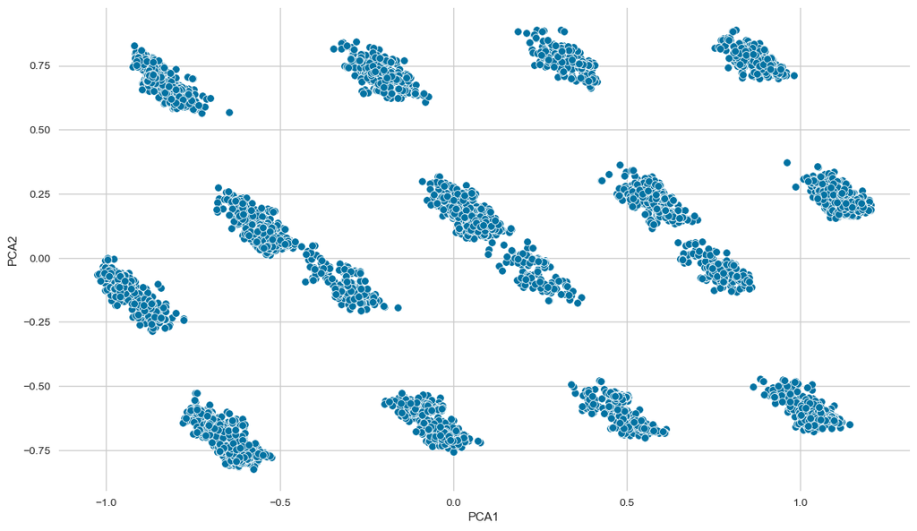

```python
fig, ax = plt.subplots(figsize = (14, 8))

sns.scatterplot(data = pca_df, x = 'PCA1', y = 'PCA2', ax = ax)

ax.spines[:].set_visible(False)

plt.show()
```

The data is ready for performing alogritms. It has completed all statistical analysis. Now for the k value, data will undergo Elbow method.

## Finding K value using Elbow method

```python
inertia = []
for i in range(1, 11):
    kmeans = KMeans(n_clusters = i, n_init = 10,random_state = 42)

    kmeans.fit(x)

    inertia.append(kmeans.inertia_)
```

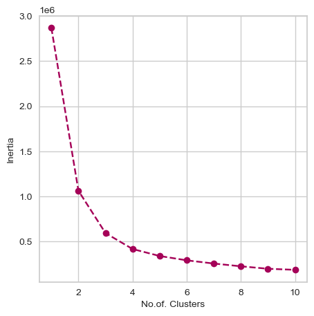

```python
fig, ax = plt.subplots(figsize = (5, 5))

ax.plot(range(1, 11), inertia, 'm--', marker='o', label = 'Inertia')

ax.set_xlabel('No.of. Clusters', fontsize = 10)
ax.set_ylabel('Inertia', fontsize = 10)

plt.show()
```

The graph is not helping to figure out the exact value of k. So in addition to this, let's find accuracy score to differenciate.

```python
kmeans = KMeans(n_clusters = 2, random_state = 0)

kmeans.fit(x)

labels = kmeans.labels_

correct_labels = sum(y == labels)

print('Accuracy score: {0:0.2f}'. format(correct_labels/float(y.size)))
```

```
Accuracy score: 0.21
```

```python
kmeans = KMeans(n_clusters = 3, random_state = 0)

kmeans.fit(x)

labels = kmeans.labels_

correct_labels = sum(y == labels)

print('Accuracy score: {0:0.2f}'. format(correct_labels/float(y.size)))
```

```
Accuracy score: 0.22
```

```python
kmeans = KMeans(n_clusters = 4, random_state = 0)

kmeans.fit(x)

labels = kmeans.labels_

correct_labels = sum(y == labels)

print('Accuracy score: {0:0.2f}'.format(correct_labels/float(y.size)))
```

```
Accuracy score: 0.41
```

```python
kmeans = KMeans(n_clusters = 5, random_state =  0)

kmeans.fit(x)

labels = kmeans.labels_

correct_labels = sum(y == labels)

print('Accuracy score: {0:0.2f}'. format(correct_labels/float(y.size)))
```

```
Accuracy score: 0.30
```

By this we can clearly see that accuracy score spiked at 4 and had a sudden drop at 5. Hence the value of 'k' would be 4.

## Applying K-means

```python
n_clusters = 4

kmeans = KMeans(n_clusters = n_clusters, n_init = 10, random_state = 42)

kmeans.fit(pca_data)
```

```
KMeans(n_clusters=4, random_state=42)
```

```python
labels = kmeans.labels_

plot = {0: 'A', 1: 'B', 2: 'C', 3:'D'}

plot_labels = [plot [val] for val in labels]

pca_df['Clusters'] = plot_labels
```

```python
df_1['Clusters'] = plot_labels
```

## Plotting the Clusters

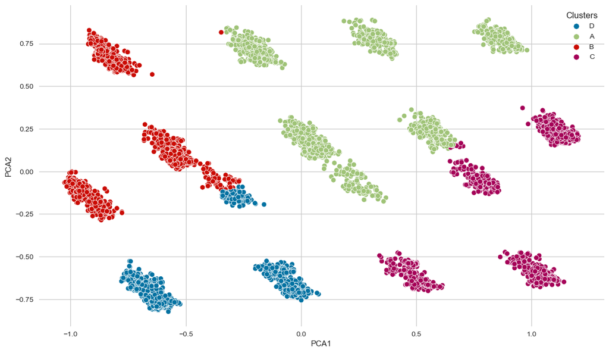

```python
fig, ax = plt.subplots(figsize = (14, 8))

sns.scatterplot(data = pca_df, x = 'PCA1', y = 'PCA2',hue = 'Clusters', ax = ax )


ax.spines[:].set_visible(False)

plt.show()
```

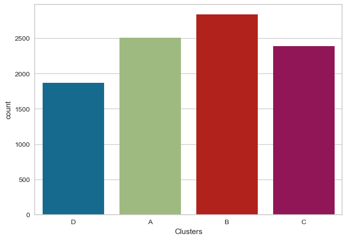

```python
cp = sns.countplot(x = pca_df['Clusters'])
plt.show()
```

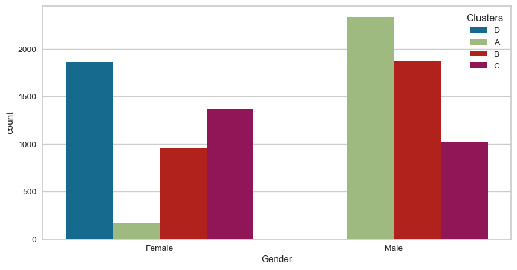

```python
fig,ax = plt.subplots(figsize = (10,5))

sns.countplot(data = df_1, x = 'Gender',hue = 'Clusters',ax = ax)

plt.show()
```

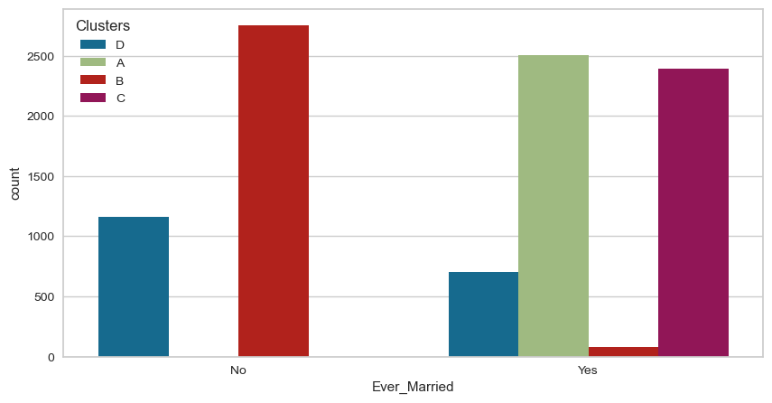

```python
fig,ax = plt.subplots(figsize = (10,5))

sns.countplot(data = df_1, x = 'Ever_Married',hue = 'Clusters',ax = ax)

plt.show()
```

```python
bins = [18,30,55,70,90]

groups = ['18-30','31-55','56-70','71-90']

df_1['age_group'] = pd.cut(df_1['Age'], bins, labels = groups)
```

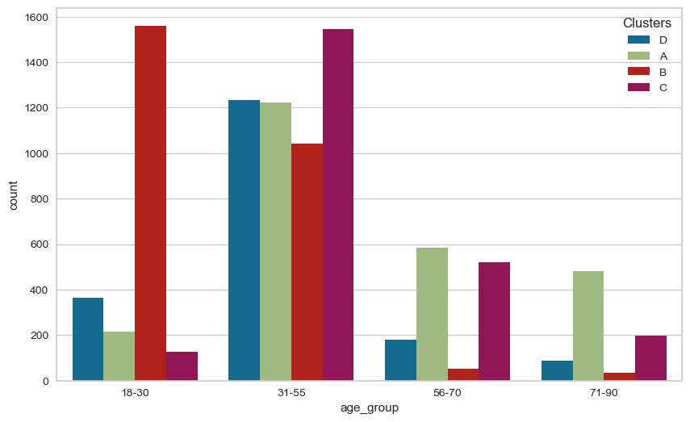

```python
fig,ax = plt.subplots(figsize = (10,6))

sns.countplot(data = df_1, x = 'age_group',hue = 'Clusters',ax = ax)

plt.show()
```

```python
df_1 = df_1.drop(['age_group'],axis = 1)
```

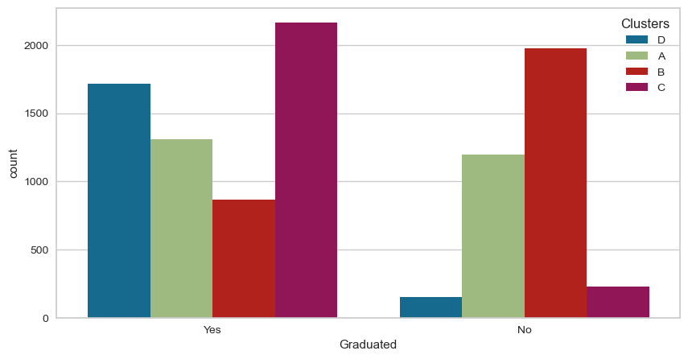

```python
fig,ax = plt.subplots(figsize = (10,5))

sns.countplot(data = df_1, x = 'Graduated',hue = 'Clusters',ax = ax)

plt.show()
```

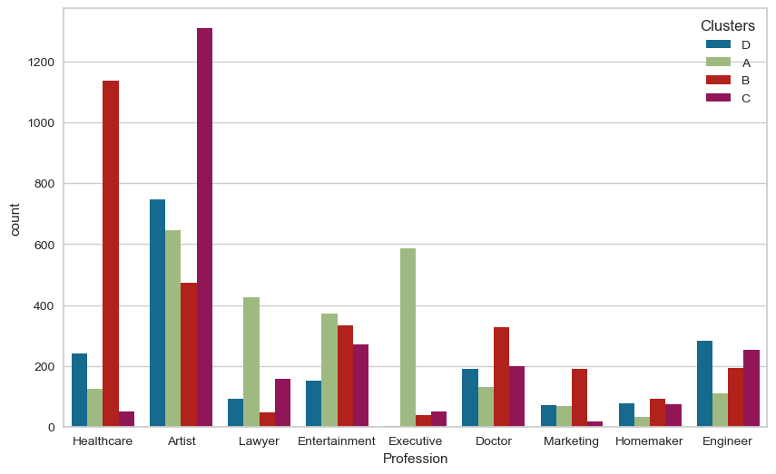

```python
fig,ax = plt.subplots(figsize = (10,6))

sns.countplot(data = df_1, x = 'Profession',hue = 'Clusters',ax = ax)

plt.show()
```

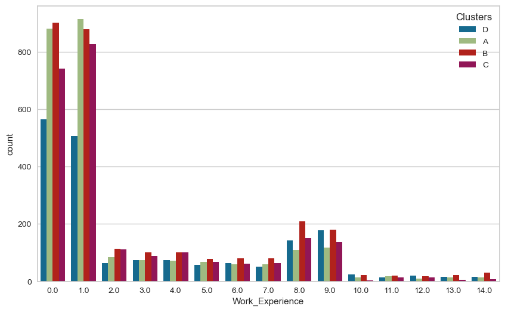

```python
fig,ax = plt.subplots(figsize = (10,6))

sns.countplot(data = df_1, x = 'Work_Experience',hue = 'Clusters',ax = ax)

plt.show()
```

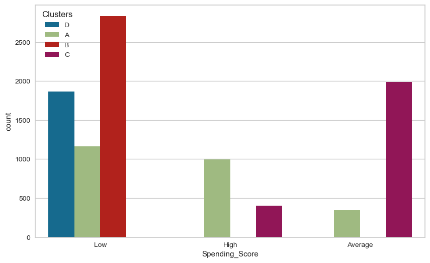

```python
fig,ax = plt.subplots(figsize = (10,6))

sns.countplot(data = df_1, x = 'Spending_Score',hue = 'Clusters',ax = ax)

plt.show()
```

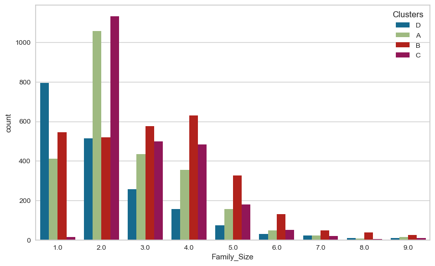

```python
fig,ax = plt.subplots(figsize = (10,6))

sns.countplot(data = df_1, x = 'Family_Size',hue = 'Clusters',ax = ax)

plt.show()
```